# Introdução à Visualização de Dados - Como escolher a melhor narrativa?

Maria Eduarda Nubié - 2021/03

- Lead Teacher at Ironhack
- Data Analytics Especialist at OLX Brasil

## Agenda

1. Data Visualization pra quê?
2. Overview Ambiente;
3. Use Case: Como escolher a visualização de dados correta;
4. Use Case: Mentindo com Estatística;
5. Conclusões;
6. Referências.

## 1. Data Visualization pra quê?

### Comunicação da análise: Qual o preço ideal para o nosso novo produto?

[figure not shown]

### 2 pérolas para 100 ostras

- Storytelling com Dados, Cole Nussbaumer Knaflic
- Análise **Explanatória** vs Análise Exploratória
- Visualização de Dados como ferramenta para explanação
- A importância do contexto
  - **O que?**
    - The Big Idea
  - **Por quê?**
    - Ações que podemos tomar?
  - **Quem?**
    - Público

### The Audience Is the Hero

[figure not shown]

- Resonate, Nancy Duarte

## 2. Overview Ambiente

- Jupyter Notebook
  - Documentação do processo
- Python - Pandas, Matplotlib, Seaborn

```python
# !pip install xlrd
import pandas as pd
import matplotlib.pyplot as plt
import numpy as np
```

```python
dist = np.random.normal(size=100)
df = pd.DataFrame(dist, columns=['dist'])
```

```python
df.head()
```

|  | dist |
| --- | --- |
| 0 | 0.736957 |
| 1 | -0.623918 |
| 2 | -0.106155 |
| 3 | -0.936327 |
| 4 | -0.598225 |

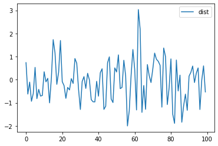

```python
df.plot(kind='line')
```

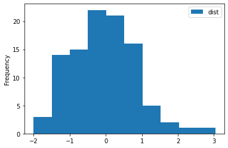

```python
df.plot(kind='hist')
```

## 3. Use Case: Como escolher a visualização de dados correta

- Startup cria novo produto para o consumidor;
- Considerações a serem feitas: preço da concorrência ao longo do tempo.

#### 3.1. Conheça seu Contexto

```python
df = pd.read_csv('https://docs.google.com/spreadsheets/d/1x6WCnM1lnQeO9oXBuahiwTLtcT0j_FYj7oto1gtEFYQ/export?format=csv')
```

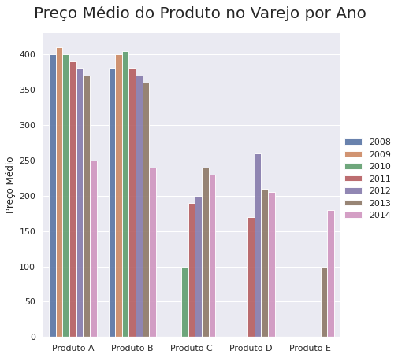

```python
import seaborn as sns
sns.set_theme(style="darkgrid")

# Draw a nested barplot by species and sex
g = sns.catplot(
    data=df, kind="bar",
    x="product", y="avg_price", hue="year",
    ci="sd", alpha=.9, height=6,
)
g.despine(left=True)
g.set_axis_labels("", "Preço Médio")
g.legend.set_title("")
g.fig.suptitle('Preço Médio do Produto no Varejo por Ano', y='1.05', fontsize=20)
```

- **Observação inicial: De uma maneira geral, o preço declinou para os produtos no mercado desde o lançamento do Produto C, em 2010**
- **Definir: Quem, o que e como?**

#### 3.2 Escolha um visual apropriado

- Precisamos trazer a tendência de preço dos produtos no decorrer do tempo
- https://www.data-to-viz.com/#explore

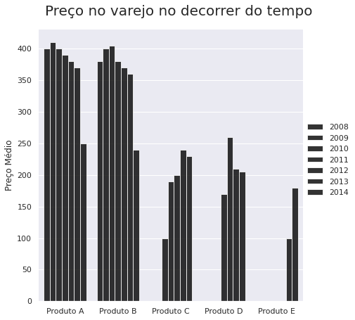

```python
import seaborn as sns
sns.set_theme(style="darkgrid")

g = sns.catplot(
    data=df, kind="bar",
    x="product", y="avg_price", hue="year",
    ci="sd", height=6,  alpha=.8, palette=sns.color_palette(['black'])
)

g.despine(left=True)
g.set_axis_labels("", "Preço Médio")
g.legend.set_title("")
g.fig.suptitle('Preço no varejo no decorrer do tempo', y='1.05', fontsize=20)
```

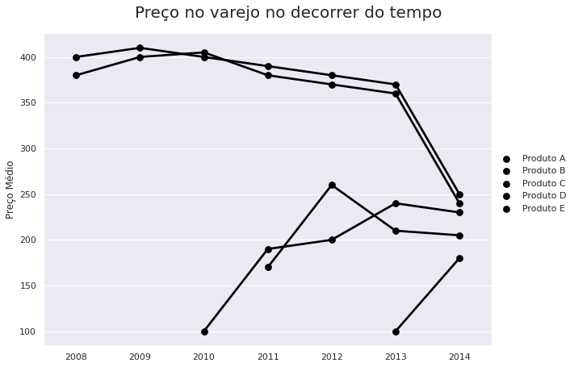

```python
import seaborn as sns
sns.set_theme(style="darkgrid")

g = sns.catplot(
    data=df, kind="point",
    x="year", y="avg_price", hue="product",
    ci="sd", height=6, aspect=11.7/8.27,
    palette=sns.color_palette(['black'])
)

g.despine(left=True)
g.set_axis_labels("", "Preço Médio")
g.legend.set_title("")
g.fig.suptitle('Preço no varejo no decorrer do tempo', y='1.05', fontsize=20)
```

#### 3.3 Eliminar a saturação e chamar atenção para onde quer

- Avaliar carga cognitiva
  - Pedir pro nosso público trabalhar -> Utilização de carga cognitiva

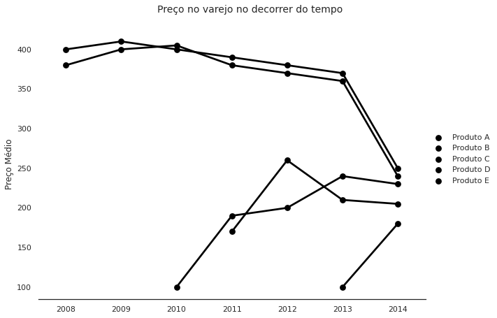

```python
# tirar grid
# diminuir a fonte
import seaborn as sns
sns.set_theme(style="white")

g = sns.catplot(
    data=df, kind="point",
    x="year", y="avg_price", hue="product",
    ci="sd", height=6, colors='black', aspect=11.7/8.27,
    palette=sns.color_palette(['black', 'black', 'black', 'black', 'black'])
)

g.despine(left=True)
g.set_axis_labels("", "Preço Médio")
g.legend.set_title("")
g.fig.suptitle('Preço no varejo no decorrer do tempo', y='1.05', fontsize=14)
```

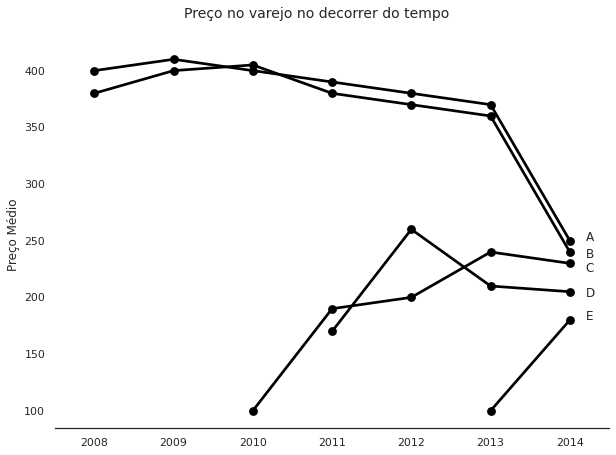

```python
# Tirar a legenda e renomear séries
import matplotlib.pylab as plt
import seaborn as sns
sns.set_theme(style="white")

g = sns.catplot(
    data=df, kind="point", legend=False,
    x="year", y="avg_price", hue="product",
    ci="sd", height=6, colors='black', aspect=11.7/8.27,
    palette=sns.color_palette(['black', 'black', 'black', 'black', 'black'])
)

g.despine(left=True)
g.set_axis_labels("", "Preço Médio")
# g.legend.set_title("")
g.fig.suptitle('Preço no varejo no decorrer do tempo', y='1.05', fontsize=14)


plt.text(x=6.2, y=250, s='A')
plt.text(x=6.2, y=235, s='B')
plt.text(x=6.2, y=222, s='C')
plt.text(x=6.2, y=200, s='D')
plt.text(x=6.2, y=180, s='E')
plt.show()
```

#### 3.4 Chame atenção para onde você quer

- Atributos pré atentivos
  - Ajudar a direcionar a atenção do público
  - Cores como atributos pré atentivos

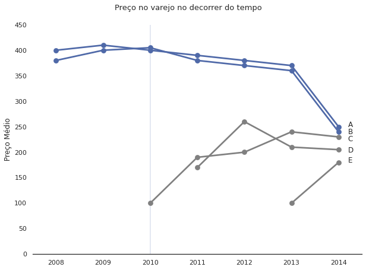

```python
import matplotlib.pylab as plt
import seaborn as sns
sns.set_theme(style="white")

g = sns.catplot(
    data=df, kind="point", legend=False,
    x="year", y="avg_price", hue="product",
    ci="sd", height=6, colors='black', aspect=11.7/8.27,
    palette=sns.color_palette(['#4f69a8', '#4f69a8', 'gray', 'gray', 'gray']),
)

g.despine(left=True)
g.set_axis_labels("", "Preço Médio")
title='''Preço no varejo no decorrer do tempo
'''
g.fig.suptitle(title, y='1.05', fontsize=13)

plt.axvline(2, color='#4f69a8', alpha=0.2)

plt.text(x=6.2, y=250, s='A')
plt.text(x=6.2, y=235, s='B')
plt.text(x=6.2, y=222, s='C')
plt.text(x=6.2, y=200, s='D')
plt.text(x=6.2, y=180, s='E')

plt.ylim(0,450)
plt.show()
```

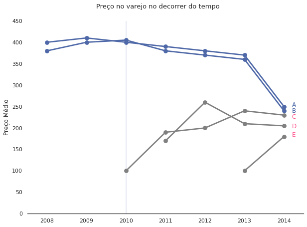

```python
# adiciona legenda
import matplotlib.pylab as plt
import seaborn as sns
sns.set_theme(style="white")

g = sns.catplot(
    data=df, kind="point", legend=False,
    x="year", y="avg_price", hue="product",
    ci="sd", height=6, colors='black', aspect=11.7/8.27,
    palette=sns.color_palette(['#4f69a8', '#4f69a8', 'gray', 'gray', 'gray']),
)

g.despine(left=True)
g.set_axis_labels("", "Preço Médio")
title='''Preço no varejo no decorrer do tempo
'''
g.fig.suptitle(title, y='1.05', fontsize=13)

plt.axvline(2, color='#4f69a8', alpha=0.2)

plt.text(x=6.2, y=250, s='A', color='#4f69a8')
plt.text(x=6.2, y=235, s='B', color='#4f69a8')
plt.text(x=6.2, y=222, s='C', color='#ff4f87')
plt.text(x=6.2, y=200, s='D', color='#ff4f87')
plt.text(x=6.2, y=180, s='E', color='#ff4f87')

plt.ylim(0,450)
plt.show()
```

**Alguns inisghts**

- Queda de preços depois do lançamento do produto C para produtos existentes;
- Preços de todos os produtos convergindo em 2014;

#### 3.5 Pense como um designer

- Peça feedbacks para outros colegas

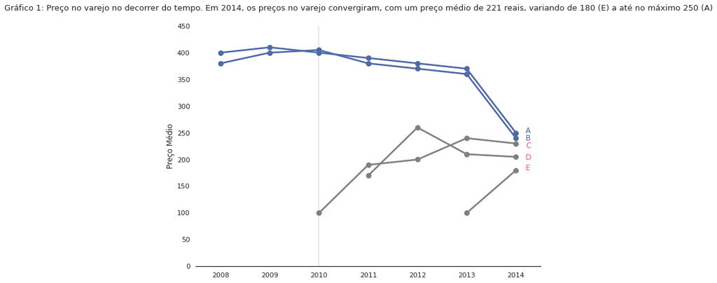

```python
# tornar visual acessível com texto
import matplotlib.pylab as plt
import seaborn as sns
sns.set_theme(style="white")

g = sns.catplot(
    data=df, kind="point", legend=False,
    x="year", y="avg_price", hue="product",
    ci="sd", height=6, colors='black', aspect=11.7/8.27,
    palette=sns.color_palette(['#4f69a8', '#4f69a8', 'gray', 'gray', 'gray']),
)

g.despine(left=True)
g.set_axis_labels("", "Preço Médio")
title='''Gráfico 1: Preço no varejo no decorrer do tempo. Em 2014, os preços no varejo convergiram, com um preço médio de 221 reais, variando de 180 (E) a até no máximo 250 (A)
'''
g.fig.suptitle(title, y='1.05', fontsize=13)

plt.axvline(2, color='#4f69a8', alpha=0.2)

plt.text(x=6.2, y=250, s='A', color='#4f69a8')
plt.text(x=6.2, y=235, s='B', color='#4f69a8')
plt.text(x=6.2, y=222, s='C', color='#ff4f87')
plt.text(x=6.2, y=200, s='D', color='#ff4f87')
plt.text(x=6.2, y=180, s='E', color='#ff4f87')

plt.ylim(0,450)
plt.show()
```

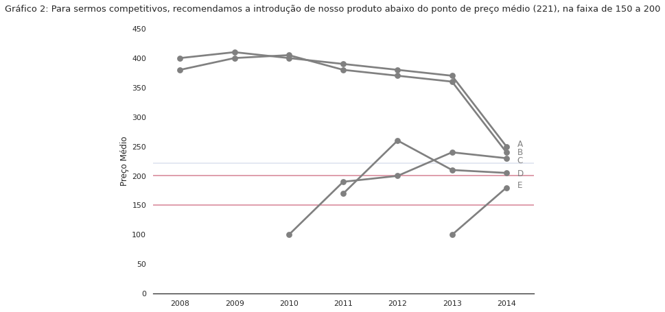

```python
# recomendação
import matplotlib.pylab as plt
import seaborn as sns
sns.set_theme(style="white")

g = sns.catplot(
    data=df, kind="point", legend=False,
    x="year", y="avg_price", hue="product",
    ci="sd", height=6, colors='black', aspect=11.7/8.27,
    palette=sns.color_palette(['gray', 'gray', 'gray', 'gray', 'gray']),
)

g.despine(left=True)
g.set_axis_labels("", "Preço Médio")
title='''Gráfico 2: Para sermos competitivos, recomendamos a introdução de nosso produto abaixo do ponto de preço médio (221), na faixa de 150 a 200
'''
g.fig.suptitle(title, y='1.05', fontsize=13)

plt.axhline(221, color='#4f69a8', alpha=0.2)
plt.axhline(200, color='#ab0025', alpha=0.5)
plt.axhline(150, color='#ab0025', alpha=0.5)

plt.text(x=6.2, y=250, s='A', color='gray')
plt.text(x=6.2, y=235, s='B', color='gray')
plt.text(x=6.2, y=222, s='C', color='gray')
plt.text(x=6.2, y=200, s='D', color='gray')
plt.text(x=6.2, y=180, s='E', color='gray')

plt.ylim(0,450)
plt.show()
```

### 4. Use Case: A temperatura global está estável?

Como mentir com Estatística, Darrel Huff

```python
import matplotlib.pyplot as plt
```

```python
data_gw= pd.read_csv('./data/GlobalTemperatures.csv')
data_gw.set_index('dt', inplace=True)
data_gw.index=pd.to_datetime(data_gw.index)
data_resample_year=data_gw.resample('A').mean()
```

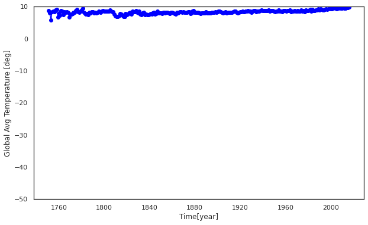

```python
fig, axes= plt.subplots(1,1, figsize=(10,6))
axes.plot(data_resample_year['LandAverageTemperature'], marker='o', color='blue')
axes.set_xlabel('Time[year]')
axes.set_ylabel('Global Avg Temperature [deg]');
axes.set_ylim(-50,10);
plt.show()
```

```python
plt.rc('xtick', labelsize=20)
plt.rc('ytick', labelsize=20)
plt.rc('font',size=20)
plt.rc('grid',color='black', linestyle =':', linewidth=0.5)
```

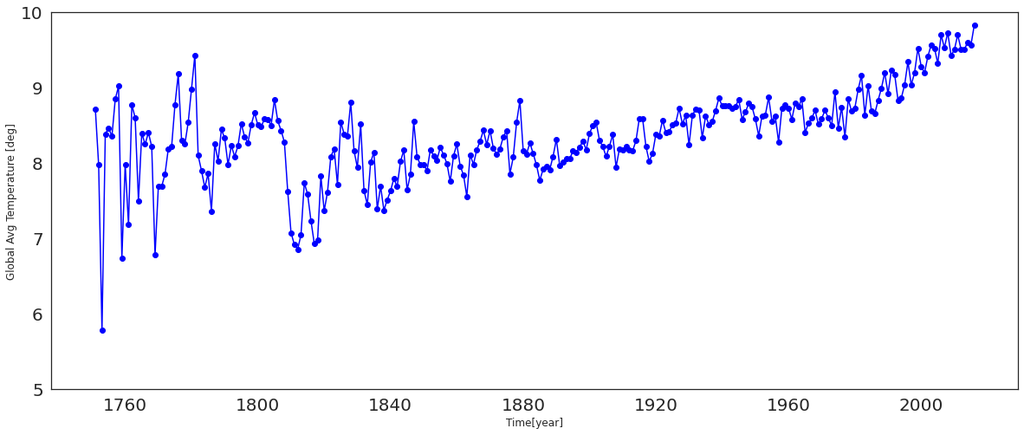

```python
fig, axes= plt.subplots(1,1, figsize=(20,8))
axes.plot(data_resample_year['LandAverageTemperature'], marker='o', color='blue')
axes.set_xlabel('Time[year]')
axes.set_ylabel('Global Avg Temperature [deg]');
axes.set_ylim(5,10);
plt.show()
```

## 5. Conclusões

- Visualização de dados é comunicação;
- Foque nas pérolas da análise exploratória;
- Seja o mentor da sua audiência;
- Foque no que importa: Elimine distrações, chame atenção para o que você quer comunicar;
- Ética e transparência sobre o que está reportando.

## 6. Referências

Apresentação

- https://www.crowdcast.io/e/english-intro-to-data-visualization - Paolo Scalia, TA Ironhack Amsterdam
- https://www.youtube.com/watch?v=8EMW7io4rSI - Cole Nussbaumer
- Resonate: Present Visual Stories that Transform Audiences
- Como Mentir com Estatística - Livro por Darrell Huff

Outros links

- https://pudding.cool/

[figure not shown]